# Class 26

## Last Class

A little bit about the final

Sonnets are the poet is speaking

First part will be similar to the midterm

Part III is a shorter less structured response

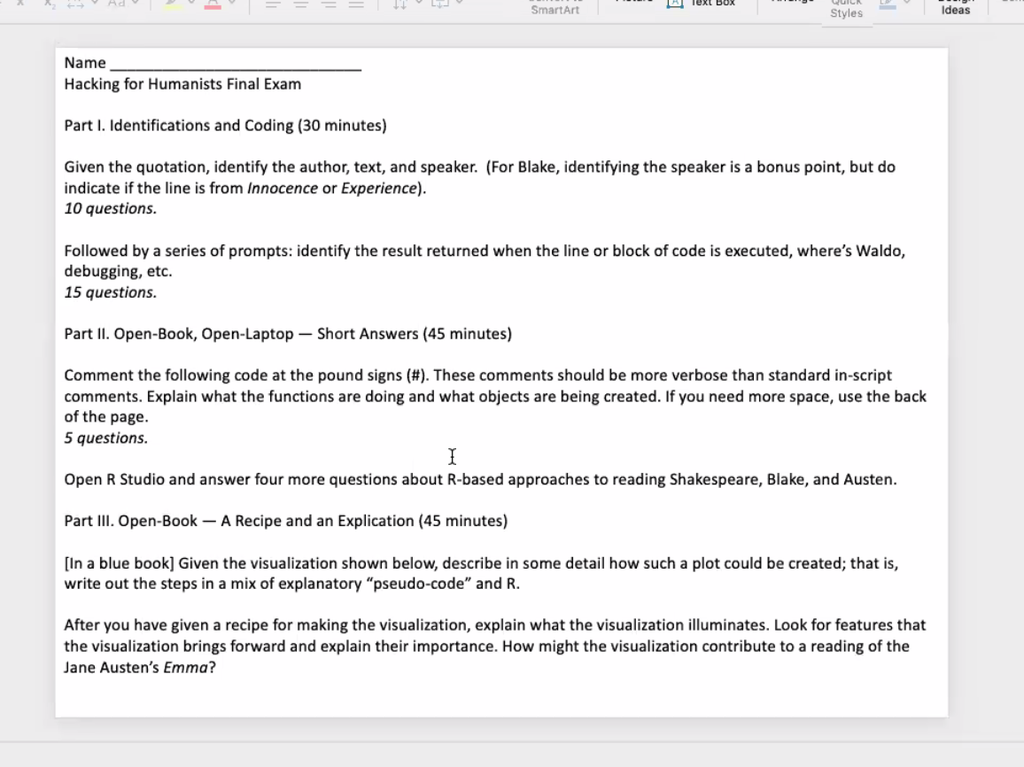

## Let’s think about visualization

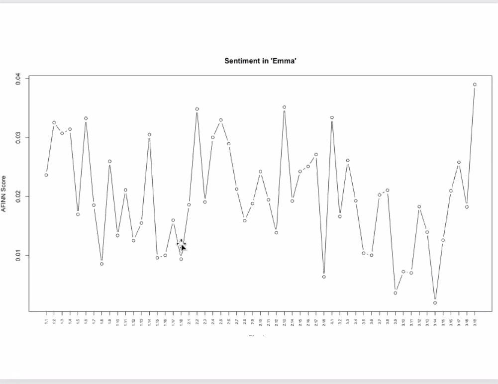

Graph is in 3 sections, Goes down, back up at start of next section, goes done, does the same thing a third time

Can see the parts of the novel in the descents

Wrestle with and try to explain what you see in the graph or visualization

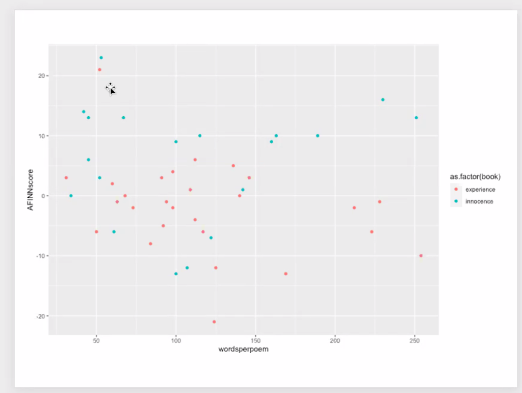

More ambiguous, just start picking at it, look at outliers

Probably would be accompanied by a table labeling the poems

An emma visualization: https://datamining.typepad.com/data_mining/2011/08/visualizing-jane-austen-part-2.html

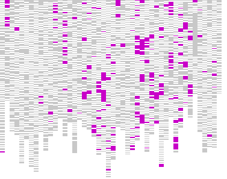

Mentions of Frank Churchill in Emma, Each column is a chapter, paragraphs are color coded

We can see the sporadic nature, see some of the flirtation in the back half

Gray streak is his letter

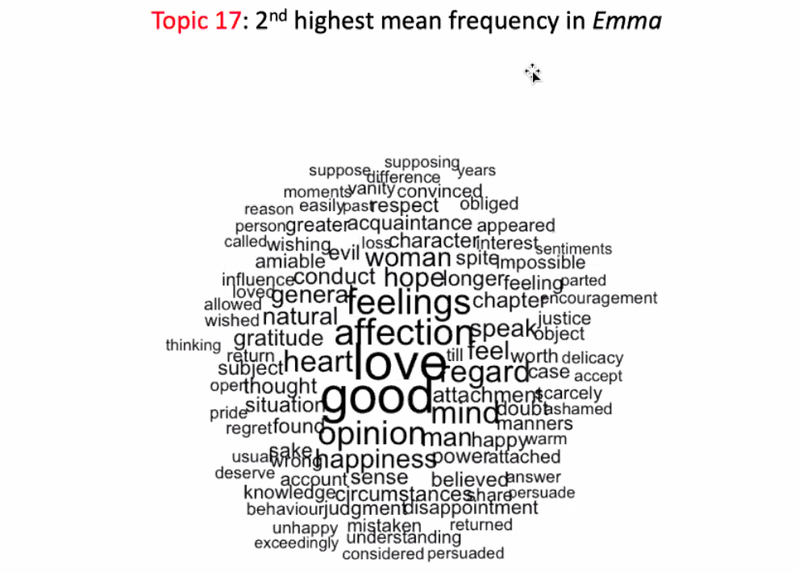

Word cloud, topic modeling A built up

Network analysis

Frank comes to town, but he is not important Mr. Knightly, man next door is who she falls for.

Box hill episode Emma says mean things to Miss Bates

## That’s it for visuals

Last question aims to merge R with the English part

Not a full blown essay

Reading from page 79 “This had just taken place … do every thing for the good of the other.”s The London Knightley’s have returned Smooth surface, emotion beneath

Or not, back to the sentiment graph

Fun to look at Sentiment graph and see if there are parts of the novel that should be higher or lower

3.7 is box hill, a higher point Emma feels mortified pg 295, regretful, internalising the Frank Knightley voice

The decline after boxhill continues down (3.9)

The language of lowness continues

3.14 is franks letter

https://www.nytimes.com/2020/02/21/movies/emma-jane-austen.html

Jane Austen has to go through social situations to develope sustense and danger

Experimenting with a secure, upper class character and poking at her insecurities

We don’t see much of the details of the profession of love. We get so little.

“Wickedly witholding”

Are any of these marriages ultimately happy?

Mr. Knightly moves into Heartfield, still living with Mr. Woodhouse Mr. Woodhouse can’t really let Emma leave

Emma brings someone else into her suffering

What do we make of Mr. Woodhouse, is he funny?

## Scripts to play with if you want

Will probably go through the finalexam script on Thursday during the review script

```r
# Hacking for Humanists
# GGPlot2
# April 24, 2019

# There's ggplot2 cheatsheet:
# https://www.rstudio.com/wp-content/uploads/2015/12/ggplot2-cheatsheet-2.0.pdf



library(ggplot2)
library(stringr)
source("RTools.R") # or open it with file.edit("~/projects/hack/RTools.R")

# Using blakecorpus and songsinorder.df -- let's regenerate these
blakecorpus<-getcorpus("songstitled")
# If you still don't have getcorpus in a handy place, source it at the bottom of this script!
str(blakecorpus) # list of 46
```

```
## List of 46
##  $ 1-inn-introduction.txt             : chr [1:121] "piping" "down" "the" "valleys" ...
##  $ 10-inn-laughingsong.txt            : chr [1:100] "when" "the" "green" "woods" ...
##  $ 11-inn-acradlesong.txt             : chr [1:165] "sweet" "dreams" "form" "a" ...
##  $ 12-inn-thedivineimage.txt          : chr [1:107] "to" "mercy" "pity" "peace" ...
##  $ 13-inn-holythursday.txt            : chr [1:125] "twas" "on" "a" "holy" ...
##  $ 14-inn-night.txt                   : chr [1:252] "the" "sun" "descending" "in" ...
##  $ 15-inn-spring.txt                  : chr [1:83] "sound" "the" "flute" "now" ...
##  $ 16-inn-nursessong.txt              : chr [1:121] "when" "the" "voices" "of" ...
##  $ 17-inn-infantjoy.txt               : chr [1:51] "i" "have" "no" "name" ...
##  $ 18-inn-adream.txt                  : chr [1:114] "once" "a" "dream" "did" ...
##  $ 19-inn-onanothersorrow.txt         : chr [1:222] "can" "i" "see" "anothers" ...
##  $ 2-inn-theshepherd.txt              : chr [1:61] "how" "sweet" "is" "the" ...
##  $ 20-exp-introduction.txt            : chr [1:90] "hear" "the" "voice" "of" ...
##  $ 21-exp-earthsanswer.txt            : chr [1:107] "earth" "rais'd" "up" "her" ...
```

[output cut: 32 more lines]

```r
######################

# Try also with Emma:
# scan in Emma

emma<-scan("austen-emma.txt",what="char",sep="\n")

# chunk by chapter -- note, this should feel like old hat...
chaps.v<-grep("CHAPTER",emma)
emma<-c(emma, "END")
end.v<-length(emma)
chaps.v<-c(chaps.v,end.v)

bagsofwords.l<-list()
vols.chs<-c(paste(1,".",1:18, sep=""), paste(2,".",1:18, sep=""),paste(3,".",1:19, sep=""))
# [1] "1.1"  "1.2"  "1.3"  "1.4"  "1.5"  "1.6"  "1.7"  "1.8"  "1.9"  "1.10" "1.11" "1.12"
# [13] "1.13" "1.14" "1.15" "1.16" "1.17" "1.18" "2.1"  "2.2"  "2.3"  "2.4"  "2.5"  "2.6"
# [25] "2.7"  "2.8"  "2.9"  "2.10" "2.11" "2.12" "2.13" "2.14" "2.15" "2.16" "2.17" "2.18"
# [37] "3.1"  "3.2"  "3.3"  "3.4"  "3.5"  "3.6"  "3.7"  "3.8"  "3.9"  "3.10" "3.11" "3.12"
# [49] "3.13" "3.14" "3.15" "3.16" "3.17" "3.18" "3.19"

for(i in 1:length(chaps.v)){
  if(i != length(chaps.v)){
    vol.ch<-vols.chs[i]
    start<-chaps.v[i]+1
    end<-chaps.v[i+1]-1
    chaptercontents.v<-emma[start:end]
    chapterwords.v<-tolower(paste(chaptercontents.v, collapse=" "))
    bagofwords.v<-unlist(strsplit(chapterwords.v, "\\W"))
    bagofwords.v<-bagofwords.v[which(bagofwords.v != "")]
    bagsofwords.l[[vol.ch]]<-bagofwords.v
  }
}

str(bagsofwords.l) # chapters chunked into bags of words, organized as a list
```

```
## List of 55
##  $ 1.1 : chr [1:3344] "emma" "woodhouse" "handsome" "clever" ...
##  $ 1.2 : chr [1:1782] "mr" "weston" "was" "a" ...
##  $ 1.3 : chr [1:1888] "mr" "woodhouse" "was" "fond" ...
##  $ 1.4 : chr [1:3564] "harriet" "smith" "s" "intimacy" ...
##  $ 1.5 : chr [1:2007] "i" "do" "not" "know" ...
##  $ 1.6 : chr [1:2798] "emma" "could" "not" "feel" ...
##  $ 1.7 : chr [1:2431] "the" "very" "day" "of" ...
##  $ 1.8 : chr [1:4345] "harriet" "slept" "at" "hartfield" ...
##  $ 1.9 : chr [1:4816] "mr" "knightley" "might" "quarrel" ...
##  $ 1.10: chr [1:2693] "though" "now" "the" "middle" ...
##  $ 1.11: chr [1:2181] "mr" "elton" "must" "now" ...
##  $ 1.12: chr [1:3285] "mr" "knightley" "was" "to" ...
##  $ 1.13: chr [1:3036] "there" "could" "hardly" "be" ...
##  $ 1.14: chr [1:2459] "some" "change" "of" "countenance" ...
```

[output cut: 41 more lines]

```r
##################

# BLAKE

# Reload dictionary, recreate function
dict<-read.delim("sentanalysis/AFINN-111.txt", header=FALSE, stringsAsFactors=FALSE) # reads a tab-separated file into adataframes
names(dict) <- c('word', 'weight')
get_sentiment_afinn <- function(bagofwords){
  result <- sum(dict[which(dict$word %in% bagofwords), "weight"])
  return(result)
}

# Apply the function to the list of texts to get scores
songs.df<-data.frame(AFINNscore = sort(sapply(blakecorpus,get_sentiment_afinn)),
                     wordsperpoem = sapply(blakecorpus,length)
                     )

# Fix sort order in Songs
library("gtools")
songs.df<-songs.df[mixedorder(rownames(songs.df)),] #requires mixedorder() {gtools}

library("tibble")
songs.df<-rownames_to_column(songs.df,"file") # can also use dplyr::add_rownames, deprecated. Hadley Wickham wants us to use tibble

# Label innocence and experience
songs.df<-as.data.frame(append(songs.df,list(book=c(rep("innocence",19),rep("experience",27))), after=1))
View(songs.df)

scenesmovie<-paste0("scene",1:52)
###########################

# EMMA

# apply the get_sentiment_afinn function to the first chapter to test
get_sentiment_afinn(bagsofwords.l[[1]]) # score is 79, Ok, whatever.
```

```
## [1] 79
```

```r
# apply the function to all the chapters in the list of bags of words
chapters.df<-data.frame(sort(sapply(bagsofwords.l,get_sentiment_afinn))) # sorted most negative to least
View(chapters.df) #most negative is vol. III, chapter 14; most positive is volume I, chapter 9. Huh, ok.

# should those scores be normalized for chapter length? Maybe.
# Build a new dataframe
chapters.df<-data.frame(sapply(bagsofwords.l,get_sentiment_afinn))

# make it prettier
library("dplyr")
chapters.df<-add_rownames(chapters.df,"vol.ch")
```

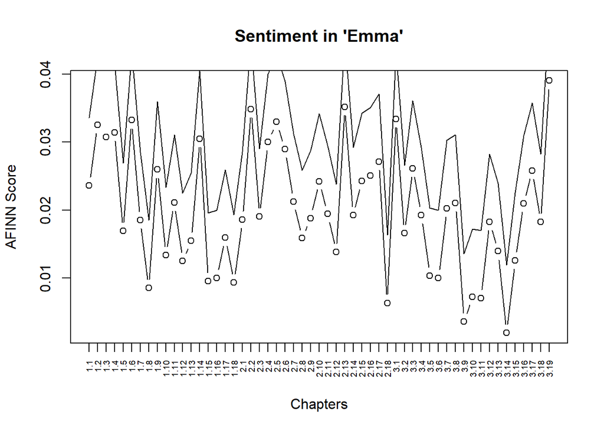

```r
colnames(chapters.df)[2]<-"AFINNscore"

# add new columns to calculate sentiment score per words in chapter
chapters.df$wordsperchap<-sapply(bagsofwords.l,length)
chapters.df$scoredperwords<-chapters.df$AFINNscore/chapters.df$wordsperchap

View(chapters.df)
# plot it to see sentiment vary over novel
plot(rownames(chapters.df), chapters.df$scoredperwords,
     type="b",
     xaxt="n",
     xlab="Chapters",
     ylab="AFINN Score")

lines((chapters.df$scoredperwords)+.01,type=)
title(main="Sentiment in 'Emma'")
axis(1,at=1:length(rownames(chapters.df)),
     labels=chapters.df$vol.ch,las=2,cex.axis=.6)
```